# LGEO2185: Introduction To R - Assignment

Author

Kristof Van Oost, Antoine Stevens & Valentin Charlier

# Assignment

Create an R script, where you plot the mean, drawn from a normal distribution as function of the sample size. You should use the following elements: * `rnorm()` function * `matrix()` * `plot()` * `for {}` Make a function where the user can change the sample size considered, and the variables of the normal distribution.

*Bonus: do not use any `for` loops :-)*

**ImportantAnswer**

# Example of a bad implementations

## Hard-coding

- Hard-coding of some parameters
- use `...` in function definition but not used within
- script within `for` loop is not indented (not needed but lacks clarity)
- The argument mean shadows the built-in `mean()` function (same for `c`). While this doesn’t immediately cause an error, it is bad practice because it can lead to confusion and bugs in more complex code where `mean()` might be expected.
- The function doesn’t return any value. While it produces a plot, the underlying data (e.g., the matrix mat) isn’t accessible for further analysis. A good practice is to return the data structure used for plotting.
- Inside the loop, the line `c <- c(2:1500)` unnecessarily creates the same vector on every iteration.

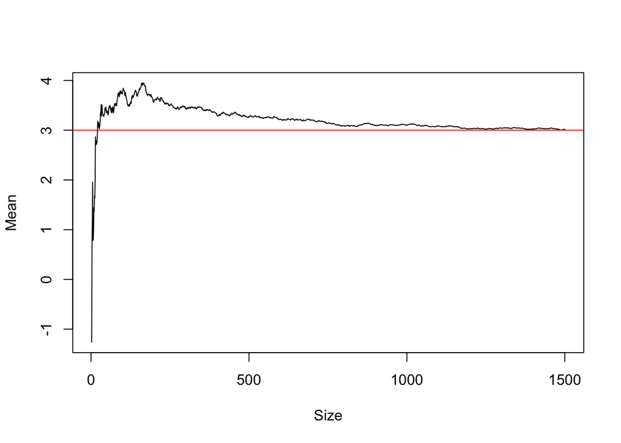

```r
myfun <- function(mean, std, ...) {
    # Generate 1500 random numbers from a normal distribution
    random <- rnorm(1500, mean = mean, sd = std)

    # Create a matrix to store the sample size and sample means
    mat <- matrix(0, nrow = 1499, ncol = 2)

    # Loop to calculate running means as sample size increases
    for (i in 2:1500) {
        moy <- mean(random[1:i]) # Calculate the mean of the first 'i' samples
        mat[i - 1, 2] <- moy # Store the mean in the second column
        c <- c(2:1500) # Vector of sample sizes from 2 to 1500
        mat[i - 1, 1] <- c[i - 1] # Store the sample size in the first column
    }

    # Name the columns of the matrix
    colnames(mat) <- c("Size", "Mean")

    # Plot the sample size vs running mean
    plot(mat, type = "l") # Line graph of sample size vs running mean
    abline(mean, 0, col = "red") # Add a red horizontal line at the population mean
}

# Test the function
myfun(3, 4)
```

## Solution(s) ?

- Well documented
- Using a relevant function name

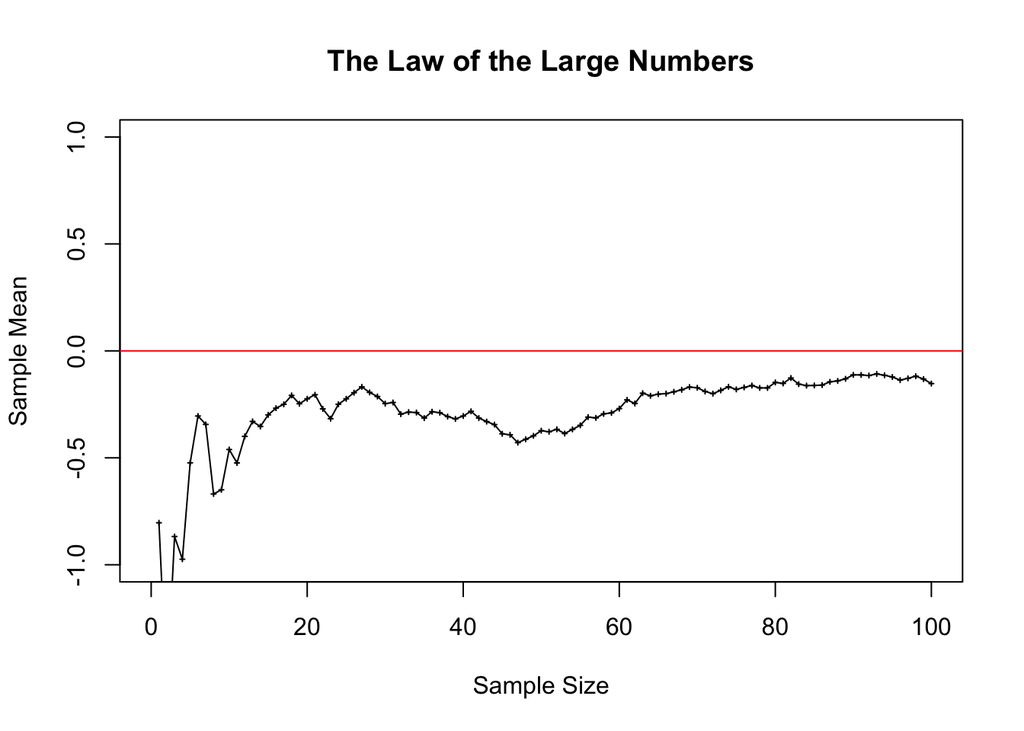

```r
# Function to create mean vs. samplesize drawn from a normal distribution
LawOfLargeNumbers <- function(samplesize, mean, stdev) {
    # samplesize: integer, number of samples
    # mean: real, population mean
    # stdev: real, population standard deviation
    # Return: vector (size = samplesize) with running means

    # Generate a population distribution with specified mean and standard deviation
    pop_dist <- rnorm(samplesize, mean = mean, sd = stdev)

    # Initialize a vector to store running means
    data_result <- c()

    # Calculate running means for increasing sample sizes
    for (i in 1:samplesize) {
        data_result[i] <- mean(pop_dist[1:i])
    }

    # Plot the running means
    plot(data_result,
        pch = 3, cex = 0.3,
        xlab = "Sample Size",
        ylab = "Sample Mean",
        xlim = c(0, samplesize),
        ylim = c(-stdev, stdev),
        main = "The Law of the Large Numbers"
    )
    lines(data_result) # Connect the points with a line
    abline(0, 0, col = "red") # Add a horizontal red line at y = 0

    # Return the vector of running means
    return(data_result)
}

# Generate running means for 100 samples, mean = 0, stdev = 1
meanvsss <- LawOfLargeNumbers(100, 0, 1)
```

```r
head(meanvsss)
```

```
[1] -0.8036380 -1.5967076 -0.8678564 -0.9741493 -0.5234445 -0.3044376
```

## Improved documentation

- Pro tip: Use `CTRL+SHIFT+R` to your function, a way to organize documentation of function parameters and that can be used to create `R` documentation files (`Rd`)

```r
#' The Law of Large Numbers
#'
#' The Law of Large Numbers states that as the sample size grows, the sample mean
#' gets closer to the population mean.
#'
#' @param samplesize Integer. The number of samples to draw from the normal distribution.
#' @param mu Numeric. The population mean of the normal distribution.
#' @param sigma Numeric. The population standard deviation of the normal distribution.
#'
#' @return A numeric vector of size \code{samplesize}, containing the running means.
#' @details The function generates a population distribution with the specified mean and
#' standard deviation, calculates the running means for increasing sample sizes,
#' and plots the running means against the sample size. A red horizontal line is drawn
#' for the given \code{mean}.
#'
#' @examples
#' # Example usage:
#' LawOfLargeNumbers(samplesize = 1000, mu = 0, sigma = 1)
#'
#' @export
LawOfLargeNumbers <- function(samplesize, mu, sigma) {
    # Generate a population distribution with specified mean and standard deviation
    pop_dist <- rnorm(samplesize, mean = mu, sd = sigma)

    # Initialize a vector to store running means
    data_result <- c()

    # Calculate running means for increasing sample sizes
    for (i in 1:samplesize) {
        data_result[i] <- mean(pop_dist[1:i])
    }

    # Plot the running means
    plot(data_result,
        pch = 3, cex = 0.3,
        xlab = "Sample Size",
        ylab = "Sample Mean",
        xlim = c(1, samplesize),
        ylim = c(mu - 3 * sigma, mu + 3 * sigma),
        main = "The Law of the Large Numbers"
    )
    lines(data_result) # Connect the points with a line
    abline(h = mu, col = "red") # Add a horizontal red line at the population mean

    # Return the vector of running means
    return(data_result)
}
```

## Instead of loops, use vectorization

```r
LawOfLargeNumbers <- function(samplesize, mu, sigma) {
    # Generate a population distribution with specified mean and standard deviation
    pop_dist <- rnorm(samplesize, mean = mu, sd = sigma)

    # Calculate running means using cumulative sums
    running_sums <- cumsum(pop_dist)
    data_result <- running_sums / seq_len(samplesize)

    # Alternative, using dplyr
    # data_result <- dplyr::cummean(pop_dist)

    # Return the vector of running means
    return(data_result)
}

head(LawOfLargeNumbers(samplesize = 1000, mu = 0, sigma = 1))
```

```
[1] -1.454508231 -0.536709027 -0.103319997 -0.005535933 -0.256522272
[6] -0.216995838
```

## Pro: Use Object-Oriented Design

This OOP approach organizes the functionality into reusable methods and encapsulates the data and operations, making it easier to extend and maintain.

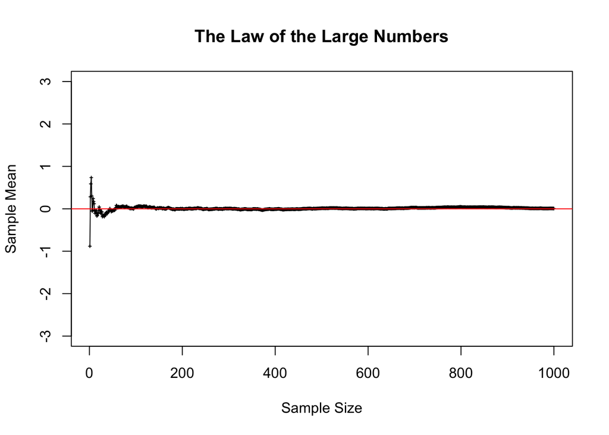

```r
#' The Law of Large Numbers (OOP with S3 Plot)
#'
#' The Law of Large Numbers states that as the sample size grows, the sample mean
#' gets closer to the population mean.
#'
#' @param samplesize Integer. The number of samples to draw from the normal distribution.
#' @param mu Numeric. The population mean of the normal distribution.
#' @param sigma Numeric. The population standard deviation of the normal distribution.
#'
#' @return An object of class \code{LawOfLargeNumbers}, containing the running means
#' and the parameters used.
#' @details The object has a custom \code{plot()} method to visualize the running means against the sample size.
#'
#' @examples
#' # Example usage:
#' lln <- LawOfLargeNumbers(samplesize = 1000, mu = 0, sigma = 1)
#' plot(lln)
#'
#' @export
LawOfLargeNumbers <- function(samplesize, mu, sigma) {
    # Generate population distribution and calculate running means
    pop_dist <- rnorm(samplesize, mean = mu, sd = sigma)
    running_sums <- cumsum(pop_dist)
    running_means <- running_sums / seq_len(samplesize)

    # Return the object with its associated class
    structure(
        list(
            samplesize = samplesize,
            mu = mu,
            sigma = sigma,
            running_means = running_means
        ),
        class = "LawOfLargeNumbers"
    )
}

# Define a plot method for the LawOfLargeNumbers class
plot.LawOfLargeNumbers <- function(x, ...) {
    # Extract information from the object
    samplesize <- x$samplesize
    mu <- x$mu
    sigma <- x$sigma
    running_means <- x$running_means

    # Create the plot
    plot(running_means,
        pch = 3, cex = 0.3,
        xlab = "Sample Size",
        ylab = "Sample Mean",
        xlim = c(1, samplesize),
        ylim = c(mu - 3 * sigma, mu + 3 * sigma),
        main = "The Law of the Large Numbers"
    )
    lines(running_means) # Connect the points with a line
    abline(h = mu, col = "red") # Add a horizontal red line at the population mean
}

# Create an object of class LawOfLargeNumbers
lln <- LawOfLargeNumbers(samplesize = 1000, mu = 0, sigma = 1)

# Plot the running means
plot(lln)
```

## Don’t forget input validation…

```r
LawOfLargeNumbers <- function(samplesize, mu, sigma) {
    # Generate a population distribution with specified mean and standard deviation
    pop_dist <- rnorm(samplesize, mean = mu, sd = sigma)

    # Calculate running means using cumulative sums
    running_sums <- cumsum(pop_dist)
    data_result <- running_sums / seq_len(samplesize)

    # Alternative, using dplyr
    # data_result <- dplyr::cummean(pop_dist)

    # Return the vector of running means
    return(data_result)
}

LawOfLargeNumbers(-100, 0, 1)
```

```
Error in rnorm(samplesize, mean = mu, sd = sigma): invalid arguments
```

```r
# Do some sanity checks
LawOfLargeNumbers <- function(samplesize, mu, sigma) {
    # Input validation
    if (!is.numeric(samplesize) || samplesize <= 0 || samplesize != as.integer(samplesize)) {
        stop("samplesize must be a positive integer.")
    }
    if (!is.numeric(mu)) stop("mu must be numeric.")
    if (!is.numeric(sigma) || sigma <= 0) stop("sigma must be a positive numeric value.")
    # Generate a population distribution with specified mean and standard deviation
    pop_dist <- rnorm(samplesize, mean = mu, sd = sigma)

    # Calculate running means using cumulative sums
    running_sums <- cumsum(pop_dist)
    data_result <- running_sums / seq_len(samplesize)

    # Alternative, using dplyr
    # data_result <- dplyr::cummean(pop_dist)

    # Return the vector of running means
    return(data_result)
}

LawOfLargeNumbers(-100, 0, 1)
```

```
Error in LawOfLargeNumbers(-100, 0, 1): samplesize must be a positive integer.
```